# Data Exploration

Play around with the data. Get a sense of what data I have and how it looks. Pay attention for signs that I need further cleaning

### Setup

```python
pylab inline
```

```python
%load_ext autoreload
```

```python
import pandas as pd
pd.options.mode.chained_assignment = 'warn'  # default='warn', None, 'raise'
#pd.options.display.memory_usage = True
import numpy as np
np.random.RandomState(100)
from sqlalchemy import create_engine
import os
import sys
sys.setrecursionlimit(3000)
from joblib import Parallel, delayed
import multiprocessing
num_cores = multiprocessing.cpu_count()
print "%s cores available for parallel processing" % num_cores
sys.path.append('mpscraper')
from mpscraper.cfgdb import cfg
sys.path.append('antools')
import antools.randomstuff as rd
import antools.miscdf as mdf
import antools.visualization as viz
import antools.random as rd
import antools.utilities as util
import seaborn as sns
sns.set_style('white')
import matplotlib.pyplot as plt
from sklearn.metrics.pairwise import pairwise_distances
```

```
4 cores available for parallel processing
```

```python
#load in preprocessed data
engine = create_engine('mysql://%s@%s/%s?charset=%s&use_unicode=%s&passwd=%s' %(cfg.user, cfg.host, cfg.dbname, cfg.charset, cfg.use_unicode, cfg.passwd), pool_recycle=3600)
cdf = pd.read_sql("SELECT * from climb_prepped", engine, index_col='index')
cldf = pd.read_sql("SELECT * from climber_prepped", engine, index_col='index')
adf = pd.read_sql("SELECT * from area_prepped", engine, index_col='index')
udf = pd.read_sql("SELECT * from climber_prepped", engine, index_col='index')
hdf= pd.read_sql("SELECT * from hits_prepped", engine, index_col='index')
sdf= pd.read_sql("SELECT * from stars_prepped", engine, index_col='index')
gdf= pd.read_sql("SELECT * from grades_prepped", engine, index_col='index')
codf= pd.read_sql("SELECT * from comments_prepped", engine, index_col='index')
```

```python
#misc config
rootdir=os.getcwd()
while 'Projects' in rootdir:
    rootdir=os.path.dirname(rootdir)
rootdir=os.path.join(rootdir, 'Projects','cragcrunch')
print rootdir
```

```
/Users/amyskerry/Documents/Projects/cragcrunch
```

### Review DataFrames

```python
cdf.head(2)
```

| index | name | climbid | area | description | grade | fa | protection | locationdescrip | pitch | style | ... | look_description | broken_description | challenging_description | crimp_description | smooth_description | fall_description | break_description | trees_description | sure_description | mergedtext |
| --- | --- | --- | --- | --- | --- | --- | --- | --- | --- | --- | --- | --- | --- | --- | --- | --- | --- | --- | --- | --- | --- |
| 8 | Scene of the Crime | 8 | 8663 | A very enjoyable climb and a good first climb ... | 5.10a/b | Tom Bowker 1990 | 5 bolts to quick clips. \n, or at least get a ... | On the left side of the cave, the next route l... | 1 | Sport | ... | 0 | 0 | 0 | 0 | 0 | 0 | 0 | 0 | 0 | The hold Lee is talking about is kind of hidde... |
| 2209 | Flying Squirrel | 2209 | 8663 | Climb above Anchovy Caper anchor to belay ledg... | 5.11a | Chris Smith | 8 bolts to bolted anchor | 2nd route on the belay ledge above anchovy cap... | 1 | Sport | ... | 0 | 0 | 0 | 0 | 0 | 0 | 0 | 0 | 0 | My wife found a bomber kneebar midway up the a... |

2 rows × 301 columns

```python
adf.head(2)
```

| index | areaid | area | name | url | mainarea | description | elevation | directions | mapref | region | country | pageviews | urlname | latitude | longitude |
| --- | --- | --- | --- | --- | --- | --- | --- | --- | --- | --- | --- | --- | --- | --- | --- |
| 5 | 5 | 4 | New Hampshire | mountainproject.com/v/new-hampshire/105872225 | NaN | New Hampshire is the Granite State. The state ... | NaN | Despite its diminutive size, New Hampshire sho... | http://maps.google.com/maps?q=43.5804,-71.7188... | World | USA | 8344320 | None | 43.5804 | -71.7188 |
| 15 | 15 | 4 | Alaska | mountainproject.com/v/alaska/105909311 | NaN | One word describes Alaska and that is "BIG!" ... | 75 | You can get to Alaska by plane, boat or automo... | http://maps.google.com/maps?q=64.7366,-150.732... | World | USA | 1071480 | None | 64.7366 | -150.7320 |

```python
udf.head(2)
```

| index | climberid | mainarea | name | url | gender | personal | age | favclimbs_parsed | favclimbs | interests | ... | aid_f | mixed_l | mixed_f | urlname | numareas | region | numhits | g_min | g_max | g_median |
| --- | --- | --- | --- | --- | --- | --- | --- | --- | --- | --- | --- | --- | --- | --- | --- | --- | --- | --- | --- | --- | --- |
| 4 | 4 | 1036.0 | Brian Boyd | nan | nan | nan | NaN | nan | nan | nan | ... | nan | nan | nan | None | 4 | Arizona | 17 | 22 | 37 | 31 |
| 7 | 7 | 669.0 | ian altman | nan | nan | nan | NaN | nan | nan | nan | ... | nan | nan | nan | None | 1 | Colorado | 3 | 40 | 46 | 46 |

2 rows × 31 columns

```python
hdf.head(2)
```

| index | climb | climber | urlname | hitsid |
| --- | --- | --- | --- | --- |
| 434 | 4789 | 1098 | john-hoffman | 434 |
| 451 | 6714 | 44 | legs-magillicutty | 451 |

```python
sdf.head(2)
```

| index | starid | starsscore | climb | climblink | climber | url | name | urlname | relative_star | other_avg | other_std |
| --- | --- | --- | --- | --- | --- | --- | --- | --- | --- | --- | --- |
| 96 | 96 | 4 | 699 | mountainproject.com/v/new-dimensions/105992537 | 10 | mountainproject.com/u/ken-duncan//13115?action... | Ken Duncan_New Dimensions | ken-duncan | 0.257143 | 3.76923 | 0.438529 |
| 122 | 122 | 4 | 724 | mountainproject.com/v/reeds-pinnacle-direct-ro... | 10 | mountainproject.com/u/ken-duncan//13115?action... | Ken Duncan_Reed's Pinnacle-Direct Route | ken-duncan | 0.296154 | 3.70312 | 0.554339 |

```python
gdf.head(2)
```

| index | gradesid | climb | climblink | climber | url | grade | name | urlname | rankdiff |
| --- | --- | --- | --- | --- | --- | --- | --- | --- | --- |
| 35 | 35 | 249 | mountainproject.com/v/right-banana-crack/10584... | 9 | mountainproject.com/u/andy-laakmann//14568?act... | 5.11b | Andy Laakmann_Right Banana Crack | andy-laakmann | 0 |
| 36 | 36 | 250 | mountainproject.com/v/route-499/105721714 | 9 | mountainproject.com/u/andy-laakmann//14568?act... | 5.11b | Andy Laakmann_Route 499 | andy-laakmann | 5 |

```python
codf.head(2)
```

| index | commentsid | climb | climblink | climber | url | comment | date | name | urlname |
| --- | --- | --- | --- | --- | --- | --- | --- | --- | --- |
| 156 | 156 | 224 | mountainproject.com/v/polymastia/106648085 | 9 | mountainproject.com/u/andy-laakmann//14568?act... | Really fun! Very well protected. A bit gritt... | 2014-04-28 | Andy Laakmann_Polymastia_Really... | andy-laakmann |
| 157 | 157 | 225 | mountainproject.com/v/keystone-corner/105874446 | 9 | mountainproject.com/u/andy-laakmann//14568?act... | No anchor up top.... easy walk off, just be aware | 2014-04-28 | Andy Laakmann_Keystone Corner_No anc... | andy-laakmann |

```python
cldf.head(2)
```

| index | climberid | mainarea | name | url | gender | personal | age | favclimbs_parsed | favclimbs | interests | ... | aid_f | mixed_l | mixed_f | urlname | numareas | region | numhits | g_min | g_max | g_median |
| --- | --- | --- | --- | --- | --- | --- | --- | --- | --- | --- | --- | --- | --- | --- | --- | --- | --- | --- | --- | --- | --- |
| 4 | 4 | 1036.0 | Brian Boyd | nan | nan | nan | NaN | nan | nan | nan | ... | nan | nan | nan | None | 4 | Arizona | 17 | 22 | 37 | 31 |
| 7 | 7 | 669.0 | ian altman | nan | nan | nan | NaN | nan | nan | nan | ... | nan | nan | nan | None | 1 | Colorado | 3 | 40 | 46 | 46 |

2 rows × 31 columns

### Characterize basic climb types/levels

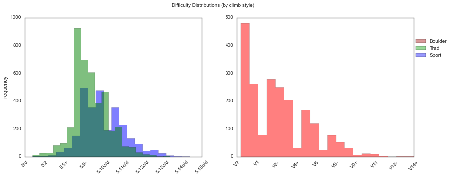

```python
%autoreload
f,axes=plt.subplots(1,2,figsize=[14,5])
plt.suptitle('Difficulty Distributions (by climb style)')
ax=axes[0]
cdf[cdf['style']=='Sport'].numerizedgrade.hist(bins=20,ax=ax, histtype="stepfilled", alpha=.5, color='blue', grid=False)
cdf[cdf['style']=='Trad'].numerizedgrade.hist(bins=20,ax=ax, histtype="stepfilled", alpha=.5, color='green', grid=False)
a=ax.set_xticklabels([rd.ndictgrades_r[g] for g in ax.get_xticks()], rotation=45)
ax.set_ylabel('frequency')
viz.customlegend({'Sport':(.2,.2,1,.5),'Trad':(.2,.7,.2,.5), 'Boulder':(.7,.2,.2,.5)}, [1,.7])
ax=axes[1]
cdf[cdf['style']=='Boulder'].numerizedgrade.hist(bins=20, ax=ax, histtype="stepfilled", alpha=.5, color='red', grid=False)
a=ax.set_xticklabels([rd.ndictbouldergrades_r[g] for g in ax.get_xticks()], rotation=45)
```

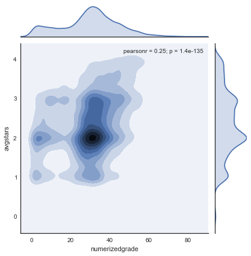

```python
#how do star ratings distribute across grades and styles?
#Do harder or easier climbs tend to be more highly rated?
sns.jointplot(x='numerizedgrade', y='avgstars', data=cdf, kind='kde')
```

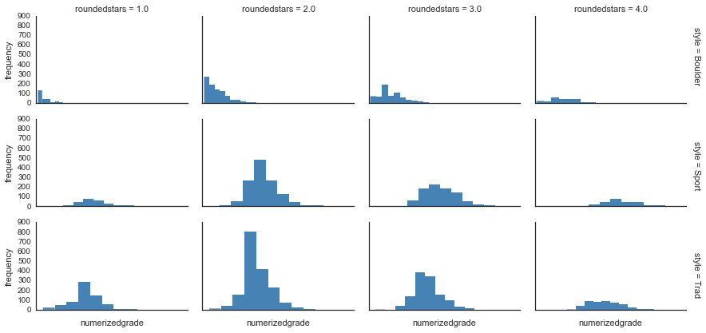

```python
#lets break that down further
plotdf=cdf[(cdf['style'].isin(['Boulder','Trad','Sport'])) & (cdf['roundedstars']>0)]
g = sns.FacetGrid(plotdf, row="style", col="roundedstars", margin_titles=True, size=2, aspect=1.5)
g.map(plt.hist, "numerizedgrade", color="steelblue", lw=0)
g.set_xticklabels([''])
g.set_ylabels('frequency')
```

### Climber Demographics

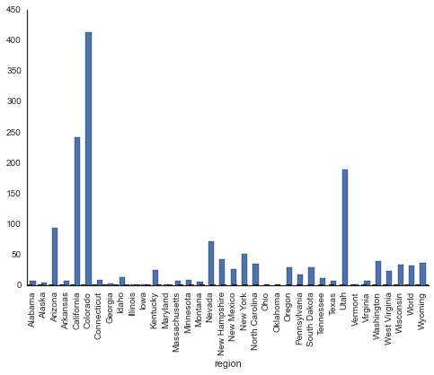

```python
#how are climbers distributed across the country (I'll be focusing on CA, but just for curiousity)
cldf.groupby('region').count().name.plot(kind='bar', grid=False)
sns.despine()
ax.set_ylabel('# climbers in region')
```

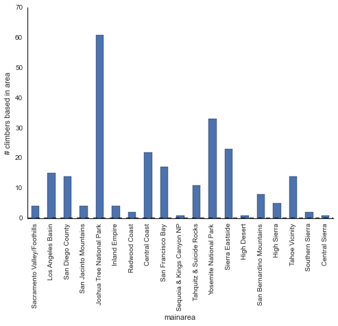

```python
#within california (target region for CragCrunch 1.0) how many climbers in each main area?
f,ax=plt.subplots()
plotdf=cldf[cldf['region']=='California'].groupby('mainarea').count()
plotdf.name.plot(kind='bar', ax=ax, grid=False)
labels=[plotdf.index.values][0]
x=ax.set_xticklabels([adf[adf['areaid']==float(a)].name.values[0] for a in labels])
ax.set_ylabel('# climbers based in area')
sns.despine()
```

### Climbing across the USA

Just for fun, I wanted to create a way to visualize how climbing varies across the USA. Even though the initial product will be limited to CA+NH, understanding the landscape of climbing across the country would eventually be imporant for thinking about the challenges that might arise in scaling this project.

```python
%autoreload
featurename='style'
mapdf=viz.measurearea(adf, cdf, featurename, agg='mode')
#mapdf[featurename]=np.round(mapdf[featurename].values)
coords, coordlabels, colordict = viz.prepmapvars(mapdf, featurename=featurename)
dmap=viz.mapfeature(coords, coordlabels, colordict, center=(36.73,-97.45),size='country')
```

[output not shown]

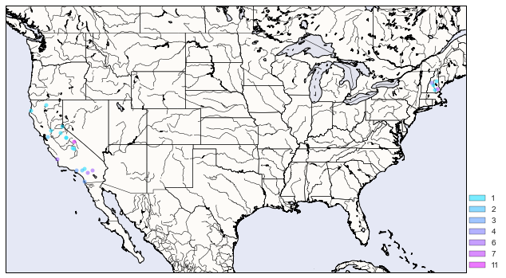

```python
#dominance of boulder styles across different areas
%autoreload
featurename='style'
#specify a condition and count # of climbs that meet the condition
tcdf=cdf[cdf[featurename]=='Boulder']
mapdf=viz.measurearea(adf, tcdf, featurename, agg='count')
mapdf[featurename]=viz.categorizecontinuous(mapdf[featurename].values, bins=10)
coords, coordlabels, colordict = viz.prepmapvars(mapdf, featurename=featurename)
dmap=viz.mapfeature(coords, coordlabels, colordict, center=(36.73,-97.45),size='country')
```

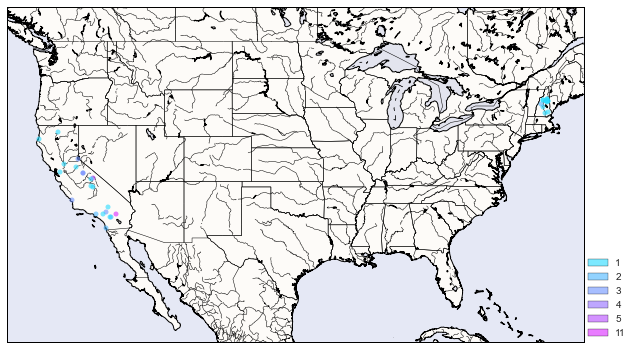

```python
#avg difficulty across different areas
%autoreload
featurename='numerizedgrade'
#specify a condition and count # of climbs that meet the condition
tcdf=cdf[cdf[featurename].between(20,40)]
mapdf=viz.measurearea(adf, tcdf, featurename, agg='count')
mapdf[featurename]=viz.categorizecontinuous(mapdf[featurename].values, bins=10)
coords, coordlabels, colordict = viz.prepmapvars(mapdf, featurename=featurename)
dmap=viz.mapfeature(coords, coordlabels, colordict, center=(36.73,-97.45),size='country')
```

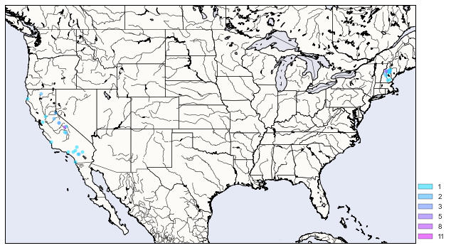

```python
#map of where climbs of different popularity/pageviews are
%autoreload
featurename='pageviews'
mapdf=viz.measurearea(adf, cdf, featurename, agg='mean')
mapdf[featurename]=viz.categorizecontinuous(mapdf[featurename].values, bins=10)
coords, coordlabels, colordict = viz.prepmapvars(mapdf, featurename=featurename)
dmap=viz.mapfeature(coords, coordlabels, colordict, center=(36.73,-97.45),size='country')
```

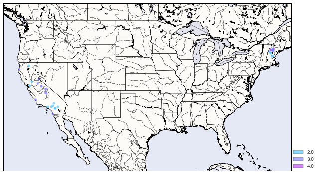

```python
#map of where climbs of different star ratings are
%autoreload
featurename='avgstars'
mapdf=viz.measurearea(adf, cdf, featurename, agg='mean')
mapdf[featurename]=np.round(mapdf[featurename].values)
coords, coordlabels, colordict = viz.prepmapvars(mapdf, featurename=featurename)
dmap=viz.mapfeature(coords, coordlabels, colordict, center=(36.73,-97.45),size='country')
```

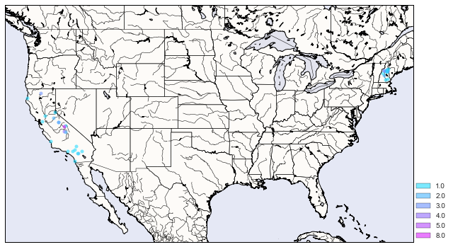

```python
#which countries have short climbs vs. long multipitch climbs
%autoreload
featurename='pitch'
mapdf=viz.measurearea(adf, cdf, featurename, agg='mean')
mapdf[featurename]=np.round(mapdf[featurename].values)
coords, coordlabels, colordict = viz.prepmapvars(mapdf, featurename=featurename)
dmap=viz.mapfeature(coords, coordlabels, colordict, center=(36.73,-97.45),size='country')
```

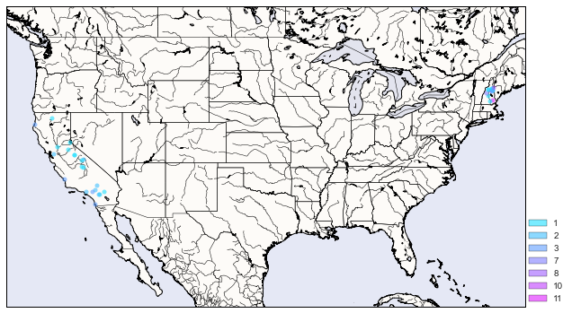

```python
#which main areas have the most crimps?
%autoreload
featurename='crimp_description'
mapdf=viz.measurearea(adf, cdf, featurename, agg='mean')
mapdf[featurename]=viz.categorizecontinuous(mapdf[featurename].values, bins=10)
coords, coordlabels, colordict = viz.prepmapvars(mapdf, featurename=featurename)
dmap=viz.mapfeature(coords, coordlabels, colordict, center=(36.73,-97.45),size='country')
```

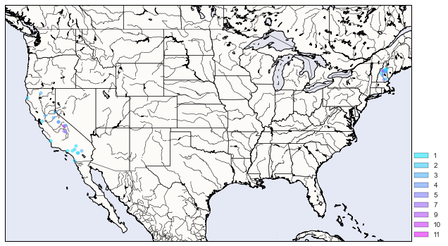

```python
#which main areas have the most cracks?
%autoreload
featurename='crack_description'
mapdf=viz.measurearea(adf, cdf, featurename, agg='mean')
mapdf[featurename]=viz.categorizecontinuous(mapdf[featurename].values, bins=10)
coords, coordlabels, colordict = viz.prepmapvars(mapdf, featurename=featurename)
dmap=viz.mapfeature(coords, coordlabels, colordict, center=(36.73,-97.45),size='country')
```

### Characterize different climbing areas

The structure of mountain project is based on a nested hierarchy of areas (e.g. a state is an area, a park is a subarea within the state, individual mountains are subareas within parks, and individual walls are subareas within mountains. However, the user generally thinks about climbing destinations at the level of "park" or large scale "main" area. I therefore focus many of my analyses on "mainareas", operationalized as any area which is a direct descendant of a US state. I plot the number of climbs and areas by region to get a sense of how climbs are distributed across the country.

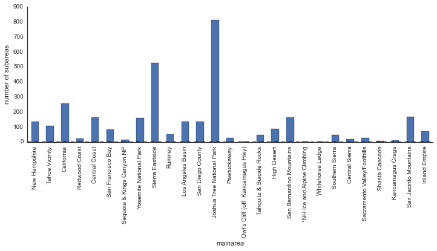

```python
#how many subareas are within each area
f,ax=plt.subplots(figsize=[12,4])
counts=adf[adf['region']!='World'].groupby('mainarea').count()
counts.name.plot(kind='bar', ax=ax, grid=False)
labels=[adf.loc[int(v),'name'] for v in counts.index.values if v in adf.index.values]
x=ax.set_xticklabels(labels)
sns.despine()
ax.set_ylabel('number of subareas')
```

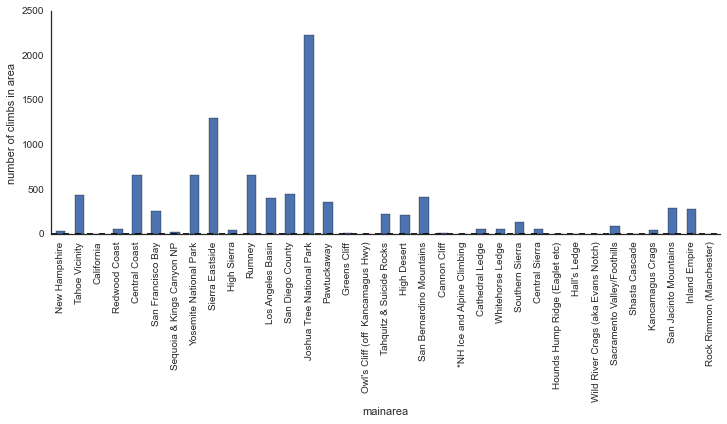

```python
#how many individual routes/problems are in each area
f,ax=plt.subplots(figsize=[12,4])
cdf.groupby('mainarea').count().name.plot(kind='bar', ax=ax, grid=False)
labels=[adf.loc[int(v),'name'] if v in adf.index.values else '' for v in cdf.groupby('mainarea').count().index.values]
x=ax.set_xticklabels(labels)
ax.set_ylabel('number of climbs in area')
sns.despine()
```

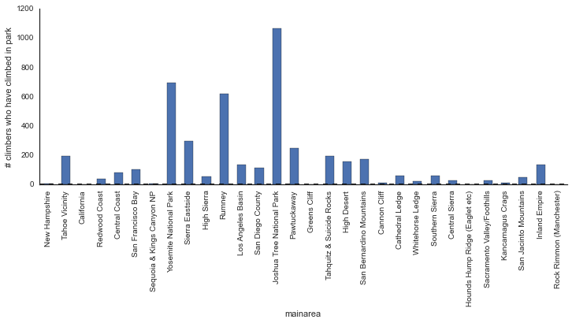

```python
#total number of climbers who haved climbed in the park
f,ax=plt.subplots(figsize=[12,4])
climbcounts=hdf.groupby('climb').count()
climbcounts['climb']=climbcounts.index.values
plotdf=pd.merge(climbcounts, cdf, left_on='climb', right_on='climbid', how='left')[['mainarea','region', 'climb','hitsid','climber','area']]
plotdf.groupby('mainarea').sum().climber.plot(kind='bar', ax=ax, grid=False)
labels=[adf.loc[int(v),'name'] for v in plotdf.groupby('mainarea').sum().index.values]
x=ax.set_xticklabels(labels)
ax.set_ylabel('# climbers who have climbed in park')
sns.despine()
```

### Explore star data

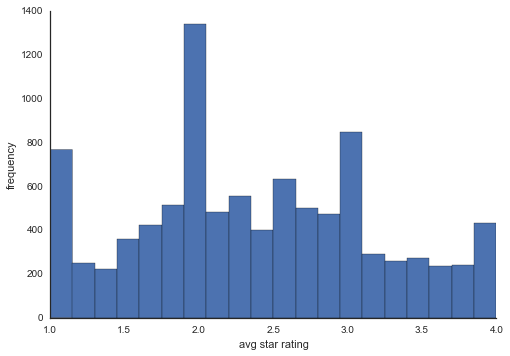

```python
#what's the distribution of average star ratings like? do climbs vary in overall popularity?
f,ax=plt.subplots()
pcdf=cdf[~(cdf['avgstars']<1)]
pcdf.avgstars.hist(bins=20, ax=ax, grid=False)
sns.despine()
ax.set_ylabel('frequency')
ax.set_xlabel('avg star rating')
```

### Some sanity checks: presumably climb ratings will be related to pageviews, number of comments, etc?

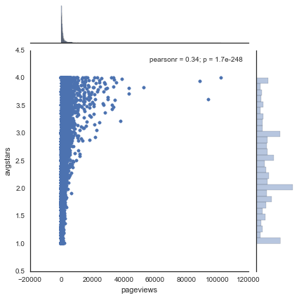

```python
keeper=cdf[~(cdf['avgstars']<1)]
sns.jointplot(data=keeper, x='pageviews', y='avgstars')
```

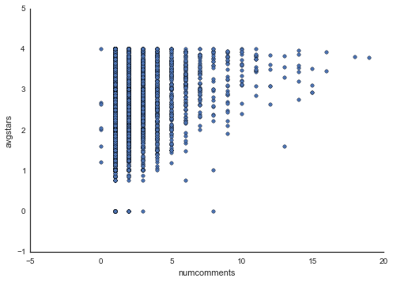

```python
#number of individual comments on the climb?
codf.groupby('climb').count().index
cdf.loc[codf.groupby('climb').count().index, 'numcomments']=codf.groupby('climb').count().climber
cdf.plot('numcomments', 'avgstars', kind='scatter', grid=False)
sns.despine()
```

### Do ratings for an individual climb vary across individuals? (i.e. do we need personalization)

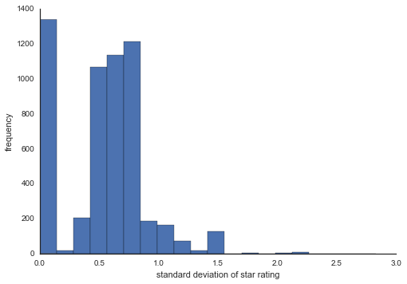

```python
f,ax=plt.subplots()
means=sdf.groupby('climb')['starsscore'].mean()
stds=sdf.groupby('climb')['starsscore'].std()
stds.hist(bins=20, grid=False)
sns.despine()
ax.set_ylabel('frequency')
ax.set_xlabel('standard deviation of star rating')
```

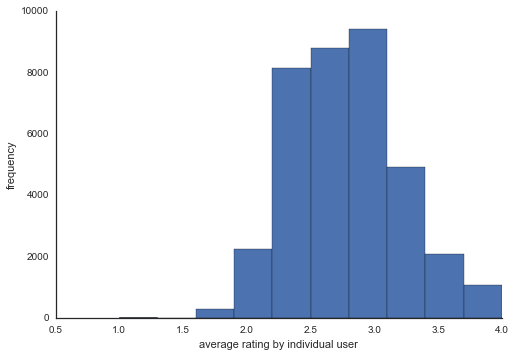

```python
#do people differ in their average ratings?
useravg=sdf[sdf['starsscore']>0]
useravg=useravg.groupby('climber').mean()[['starsscore']]
useravg['climber']=useravg.index.values
useravg=useravg.rename(columns={'starsscore':'useravg'})
plotdf=pd.merge(sdf, useravg, on='climber', how='right')
plotdf['useravg'].hist(grid=False)
sns.despine()
plt.ylabel('frequency')
plt.xlabel('average rating by individual user')
```

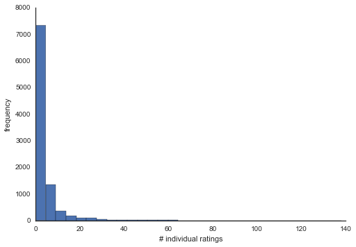

```python
#How many individual user ratings do we have for each climb?
cdf.starcounts.hist(bins=30,grid=False)
sns.despine()
plt.xlabel('# individual ratings')
plt.ylabel('frequency')
```

### Initial Feature Selection: What kind of text is unique to rock climbing comments and descriptions?

There are a number of strongly valence words that might predict ratings, but in a very general way. These words might have very little to do with climbing, and provide little information when it comes to personalized recommendations (e.g. moving beyond overall popularity). To identify an initial space of climbing-specific features, I pull a non-climbing corpora of rating-associated text from Rotten Tomatoes. So I will have a set of text reviews related and not related to climbing.

freqdf=mdf.maketextcomparedf(cdf)

```python
from nltk.tokenize import wordpunct_tokenize
from nltk.stem import WordNetLemmatizer as stemmer
from sklearn.feature_extraction.text import TfidfVectorizer
stemmer=stemmer()
```

for each climb, combined comments and descriptions into single text blob, and used CountVectorizer to compute the frequency of each text feature in the blob. I will also normalize this value by the length of the text (see Notebook 3) to generate a single score (proportion of blob word count that is the feature) for each text feature for each climb.

```python
#prep text
tokens=[word_tokenize(s) for s in freqdf['string'].values]
stemmedstrings=[' '.join([stemmer.lemmatize(w) for w in row]) for row in tokens]
```

```python
tfidf=TfidfVectorizer(stop_words='english')
tfidfmatrix=tfidf.fit_transform(stemmedstrings)
mat=tfidfmatrix.toarray()
```

computed tf-idf for each review/text blob and averaged the tf-idf scores within climbing and non-climbing text. then, subtracted the non-climbing averages from the climbing tf-idf averages and selected the 500 words that had the highest difference score. these are the top "climbing-specific" text features.

```python
xdf=pd.DataFrame(columns=tfidf.get_feature_names(), data=mat)
xdf['kind']=freqdf['kind'].values
xdf['label']=freqdf['label'].values
exclcols=[]
for c in xdf.columns:
    if c[-2:]=='ft':
        exclcols.append(c)
    if np.any([l.isdigit() for l in c]):
        exclcols.append(c)
keepercolumns=[c for c in xdf.columns if c not in exclcols]
xdf=xdf[keepercolumns]
```

```python
climbterms=xdf.groupby('kind').mean().loc['RC',:]
movieterms=xdf.groupby('kind').mean().loc['RT',:]
fdiffs=climbterms-movieterms
fdiffs.sort(ascending=False)
sets=xdf.groupby(['kind', 'label']).mean()
#RCdiffs=np.abs(sets.values[1,:]-sets.values[0,:])
#RTdiffs=np.abs(sets.values[3,:]-sets.values[2,:])
#ddiffs=pd.Series(RCdiffs-RTdiffs, index=sets.columns)
#ddiffs.sort(ascending=False)
```

```python
def gettop(diffs, allterms, topn=300):
    selected=diffs.iloc[:topn].index.values
    return list(selected)
climbingterms=gettop(fdiffs, allterms, topn=500) #terms that are unusually frequent in climbing content
```

```python
util.pickletheseobjects(os.path.join(rootdir,'data', 'allclimbingterms.pkl'), [climbingterms])
```

```python
str(', '.join(climbingterms))
```

```
'pitch, bolt, climb, crack, right, belay, route, ledge, corner, anchor, climbing, foot, face, roof, tree, gear, chimney, traverse, rope, flake, slab, crux, continue, rock, wall, facing, steep, bolted, follow, start, small, past, base, trail, summit, section, large, cam, easy, rappel, rap, gully, dih…
```